# Verify the Claim: Poverty Change in Philadelphia

- Show All Code
- Hide All Code
- View Source

Author

Lang Tao

Published

September 24, 2026

## Part 1 — Reconstruct

The [article by Alfred Lubrano (2018)](https://whyy.org/articles/new-census-figures-on-philly-neighborhoods-show-inequality-high-numbers-of-whites-living-in-poverty/) compares poverty rates in Philadelphia between the 2006–2010 and 2013–2017 American Community Survey (ACS) five-year estimates. Because the article does not identify the census tracts that make up each informal neighborhood, I analyze poverty at the census-tract level instead of trying to reproduce its neighborhood values exactly.

I use ACS table `B17001`, *Poverty Status in the Past 12 Months by Sex by Age*. `B17001_001` is the population for whom poverty status is determined, and `B17001_002` is the number of people below the poverty level. The poverty rate is therefore `B17001_002 / B17001_001`. I use ACS 5-year estimates because the article uses them and they are available for census tracts. The periods do not overlap: they cover 2006–2010 and 2013–2017. Each figure nevertheless pools five years of survey responses rather than representing a single-year count.

```r
poverty_vars <- c(
  poverty_universe = "B17001_001",
  below_poverty = "B17001_002"
)

philly_2010 <- get_acs(
  geography = "tract",
  state = "PA",
  county = "Philadelphia",
  variables = poverty_vars,
  year = 2010,
  survey = "acs5",
  output = "wide"
)

philly_2017 <- get_acs(
  geography = "tract",
  state = "PA",
  county = "Philadelphia",
  variables = poverty_vars,
  year = 2017,
  survey = "acs5",
  output = "wide"
)
```

## Part 2 — Test

### Calculate rates, margins of error, and reliability

```r
tract_2010 <- philly_2010 |>
  transmute(
    GEOID,
    tract = NAME,
    universe_2010 = poverty_universeE,
    universe_moe_2010 = poverty_universeM,
    poverty_2010 = below_povertyE,
    poverty_count_moe_2010 = below_povertyM
  )

tract_2017 <- philly_2017 |>
  transmute(
    GEOID,
    universe_2017 = poverty_universeE,
    universe_moe_2017 = poverty_universeM,
    poverty_2017 = below_povertyE,
    poverty_count_moe_2017 = below_povertyM
  )

tract_poverty <- tract_2010 |>
  inner_join(tract_2017, by = "GEOID") |>
  mutate(
    rate_2010 = poverty_2010 / universe_2010,
    rate_moe_2010 = moe_prop(
      poverty_2010, universe_2010,
      poverty_count_moe_2010, universe_moe_2010
    ),
    rate_2017 = poverty_2017 / universe_2017,
    rate_moe_2017 = moe_prop(
      poverty_2017, universe_2017,
      poverty_count_moe_2017, universe_moe_2017
    ),
    # ACS MOEs use a 90% confidence level, so divide by 1.645 to obtain SE.
    cv_2010 = (rate_moe_2010 / 1.645) / rate_2010 * 100,
    cv_2017 = (rate_moe_2017 / 1.645) / rate_2017 * 100,
    reliability_2010 = case_when(
      cv_2010 < 12 ~ "● Reliable",
      cv_2010 <= 40 ~ "▲ Somewhat reliable",
      TRUE ~ "✖ Unreliable"
    ),
    reliability_2017 = case_when(
      cv_2017 < 12 ~ "● Reliable",
      cv_2017 <= 40 ~ "▲ Somewhat reliable",
      TRUE ~ "✖ Unreliable"
    ),
    change = rate_2017 - rate_2010,
    change_moe = sqrt(rate_moe_2010^2 + rate_moe_2017^2),
    statistically_detectable = abs(change) > change_moe
  )

# A zero poverty universe means a poverty rate and its CV are undefined.
missing_tracts <- tract_poverty |>
  filter(is.na(rate_2010) | is.na(rate_2017))

analytic_tracts <- tract_poverty |>
  filter(!is.na(rate_2010), !is.na(rate_2017))
```

Eight tracts have an undefined rate in at least one period. In each case, the ACS poverty universe is zero in at least one year; these are nonresidential or otherwise very low-population areas, not evidence of a zero poverty rate. I exclude them from rate, reliability, and change calculations because a ratio with a zero denominator is undefined. This leaves 376 tracts for analysis.

```
# A tibble: 8 × 4
  GEOID       tract                                  universe_2010 universe_2017
  <chr>       <chr>                                          <dbl>         <dbl>
1 42101005000 Census Tract 50, Philadelphia County,…             0             0
2 42101980300 Census Tract 9803, Philadelphia Count…             0             0
3 42101980400 Census Tract 9804, Philadelphia Count…             0             0
4 42101980500 Census Tract 9805, Philadelphia Count…             0             0
5 42101980600 Census Tract 9806, Philadelphia Count…            92             0
6 42101980700 Census Tract 9807, Philadelphia Count…             0             0
7 42101980800 Census Tract 9808, Philadelphia Count…             0             0
8 42101980900 Census Tract 9809, Philadelphia Count…             0             0
```

### Reliability table

Reliability of Philadelphia tract poverty-rate estimates

| Census tract | 2006–10 rate | 2006–10 CV (%) | 2006–10 reliability | 2013–17 rate | 2013–17 CV (%) | 2013–17 reliability |
| --- | --- | --- | --- | --- | --- | --- |
| Census Tract 9891, Philadelphia County, Pennsylvania | 69.1% | 18.2 | ▲ Somewhat reliable | 92.5% | 144.9 | ✖ Unreliable |
| Census Tract 9800, Philadelphia County, Pennsylvania | 83.8% | 16.3 | ▲ Somewhat reliable | 4.9% | 85.6 | ✖ Unreliable |
| Census Tract 231, Philadelphia County, Pennsylvania | 0.0% | Inf | ✖ Unreliable | 0.8% | 66.7 | ✖ Unreliable |
| Census Tract 256, Philadelphia County, Pennsylvania | 10.6% | 33.7 | ▲ Somewhat reliable | 3.6% | 64.7 | ✖ Unreliable |
| Census Tract 9801, Philadelphia County, Pennsylvania | 0.0% | Inf | ✖ Unreliable | 13.3% | 61.5 | ✖ Unreliable |
| Census Tract 386, Philadelphia County, Pennsylvania | 7.5% | 54.8 | ✖ Unreliable | 3.0% | 59.3 | ✖ Unreliable |
| Census Tract 9802, Philadelphia County, Pennsylvania | 22.2% | 63.2 | ✖ Unreliable | 11.5% | 51.4 | ✖ Unreliable |
| Census Tract 340, Philadelphia County, Pennsylvania | 5.3% | 40.8 | ✖ Unreliable | 9.7% | 47.9 | ✖ Unreliable |
| Census Tract 347.02, Philadelphia County, Pennsylvania | 7.4% | 39.2 | ▲ Somewhat reliable | 2.0% | 47.1 | ✖ Unreliable |
| Census Tract 10.02, Philadelphia County, Pennsylvania | 10.5% | 53.9 | ✖ Unreliable | 6.4% | 46.7 | ✖ Unreliable |
| Census Tract 220, Philadelphia County, Pennsylvania | 3.6% | 55.0 | ✖ Unreliable | 1.3% | 45.4 | ✖ Unreliable |
| Census Tract 363.03, Philadelphia County, Pennsylvania | 8.2% | 36.6 | ▲ Somewhat reliable | 5.7% | 44.2 | ✖ Unreliable |
| Census Tract 29, Philadelphia County, Pennsylvania | 18.0% | 21.7 | ▲ Somewhat reliable | 17.6% | 43.4 | ✖ Unreliable |
| Census Tract 341, Philadelphia County, Pennsylvania | 11.8% | 24.3 | ▲ Somewhat reliable | 9.8% | 42.4 | ✖ Unreliable |
| Census Tract 365.01, Philadelphia County, Pennsylvania | 12.5% | 29.8 | ▲ Somewhat reliable | 12.6% | 42.2 | ✖ Unreliable |
| Census Tract 8.01, Philadelphia County, Pennsylvania | 5.6% | 35.7 | ▲ Somewhat reliable | 13.9% | 41.9 | ✖ Unreliable |
| Census Tract 4.02, Philadelphia County, Pennsylvania | 8.3% | 32.3 | ▲ Somewhat reliable | 4.3% | 41.5 | ✖ Unreliable |
| Census Tract 236, Philadelphia County, Pennsylvania | 9.9% | 70.8 | ✖ Unreliable | 10.4% | 41.1 | ✖ Unreliable |
| Census Tract 366, Philadelphia County, Pennsylvania | 2.9% | 68.1 | ✖ Unreliable | 4.8% | 40.6 | ✖ Unreliable |
| Census Tract 356.02, Philadelphia County, Pennsylvania | 8.4% | 50.6 | ✖ Unreliable | 2.5% | 40.3 | ✖ Unreliable |
| Census Tract 235, Philadelphia County, Pennsylvania | 4.8% | 71.6 | ✖ Unreliable | 9.3% | 40.0 | ✖ Unreliable |
| Census Tract 365.02, Philadelphia County, Pennsylvania | 2.3% | 51.4 | ✖ Unreliable | 6.7% | 40.0 | ✖ Unreliable |
| Census Tract 352, Philadelphia County, Pennsylvania | 2.7% | 33.4 | ▲ Somewhat reliable | 5.9% | 40.0 | ▲ Somewhat reliable |
| Census Tract 10.01, Philadelphia County, Pennsylvania | 2.2% | 70.4 | ✖ Unreliable | 5.9% | 39.9 | ▲ Somewhat reliable |
| Census Tract 40.02, Philadelphia County, Pennsylvania | 12.9% | 24.0 | ▲ Somewhat reliable | 7.2% | 39.5 | ▲ Somewhat reliable |
| Census Tract 12.01, Philadelphia County, Pennsylvania | 5.7% | 39.1 | ▲ Somewhat reliable | 3.0% | 39.4 | ▲ Somewhat reliable |
| Census Tract 385, Philadelphia County, Pennsylvania | 7.2% | 59.6 | ✖ Unreliable | 7.0% | 39.2 | ▲ Somewhat reliable |
| Census Tract 344, Philadelphia County, Pennsylvania | 7.5% | 25.9 | ▲ Somewhat reliable | 5.4% | 38.6 | ▲ Somewhat reliable |
| Census Tract 362.03, Philadelphia County, Pennsylvania | 9.2% | 30.5 | ▲ Somewhat reliable | 5.2% | 38.5 | ▲ Somewhat reliable |
| Census Tract 361, Philadelphia County, Pennsylvania | 8.8% | 43.8 | ✖ Unreliable | 14.3% | 38.5 | ▲ Somewhat reliable |

[output cut: 346 more lines]

Source: U.S. Census Bureau, ACS 5-year estimates. CV thresholds from Jurjevich et al. (2018): ● < 12% reliable; ▲ 12–40% somewhat reliable; ✖ > 40% unreliable.

### Are estimated changes distinguishable from zero?

```r
test_summary <- analytic_tracts |>
  summarise(
    tracts_tested = n(),
    detectable_change = sum(statistically_detectable),
    no_detectable_change = sum(!statistically_detectable),
    detectable_increase = sum(statistically_detectable & change > 0),
    detectable_decrease = sum(statistically_detectable & change < 0)
  )

test_summary
```

```
# A tibble: 1 × 5
  tracts_tested detectable_change no_detectable_change detectable_increase
          <int>             <int>                <int>               <int>
1           376                63                  313                  36
# ℹ 1 more variable: detectable_decrease <int>
```

The margin of error of the change is calculated as `sqrt(MOE_2010^2 + MOE_2017^2)`. Because ACS MOEs are 90% confidence intervals, a tract’s change is statistically distinguishable from zero when its absolute change is larger than this combined MOE. Of the 376 usable tracts, 63 show a statistically detectable change: 36 increases and 27 decreases. The other 313 tracts do not show a detectable change at the 90% confidence level.

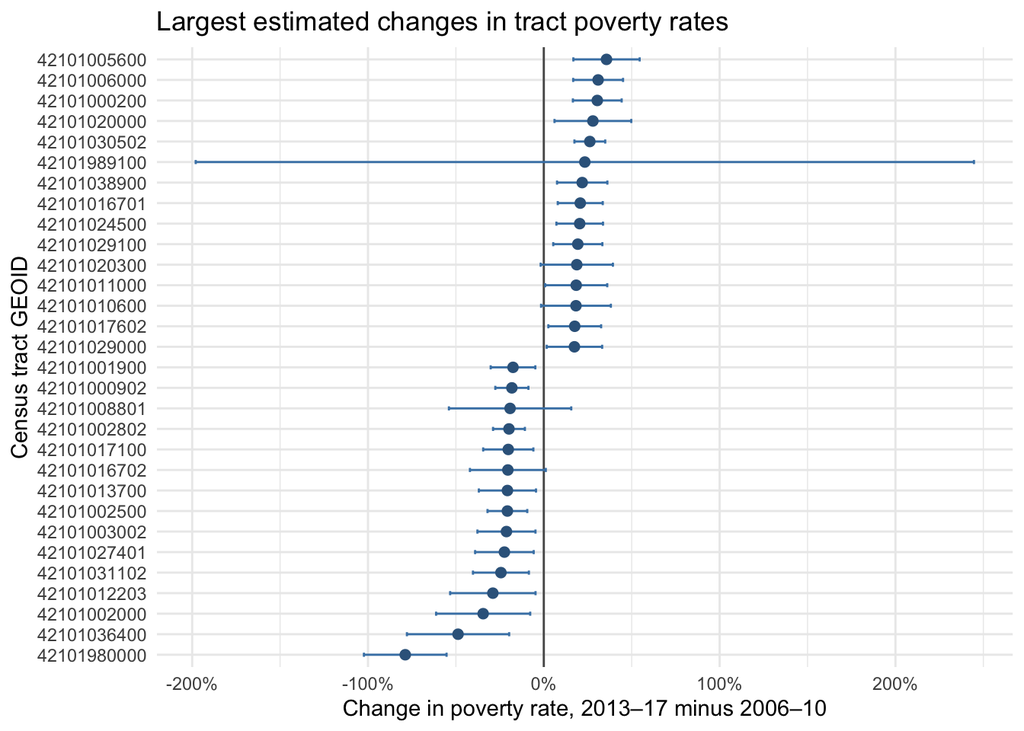

The 30 Philadelphia tracts with the largest absolute estimated poverty-rate changes. Error bars are 90% margins of error; an interval crossing zero is not statistically distinguishable from zero.

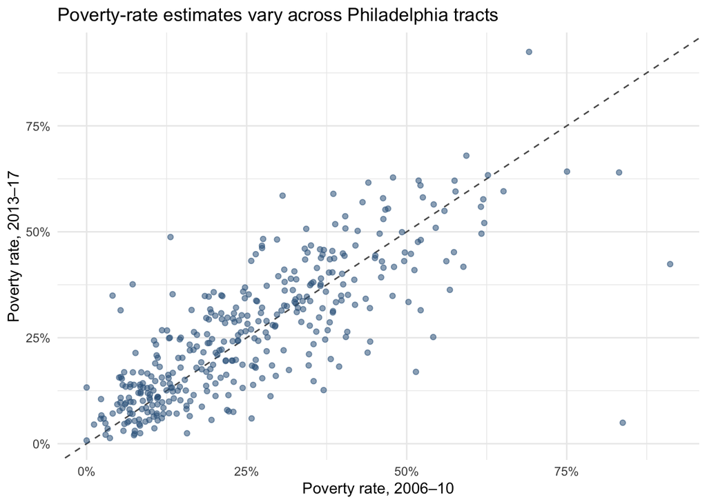

Each point is a Philadelphia census tract. Points above the line had a higher estimated poverty rate in 2013–17 than in 2006–10.

## Part 3 — Adjudicate

The article’s statement that Philadelphia had about a 26% poverty rate in the 2013–17 ACS is supported: aggregating the tract estimates gives a rate of about 25.8%, which rounds to 26%. The tract-level evidence also supports the more limited statement that some Philadelphia places experienced measurable changes in estimated poverty rates. Thirty-six tracts had statistically detectable increases, while 27 had detectable decreases.

The broad suggestion that poverty rose robustly throughout Philadelphia is not supported by this tract-level test: 313 of 376 usable tracts have changes that are not distinguishable from zero at 90% confidence. The article’s exact claims about Fairhill, Eastwick, and Holmesburg cannot be determined from this analysis. Those places are informal neighborhoods, and the article does not publish the tract-to-neighborhood boundaries it used. The Holmesburg claim also requires a separate analysis of poverty among White residents, which is not measured by the all-resident poverty rate used here.

## Part 4 — Rewrite

New five-year Census estimates show that poverty remained widespread in Philadelphia in 2013–17, when about 25.8% of residents with a determined poverty status were below the federal poverty line. At the census-tract level, some places saw statistically detectable changes from 2006–10: 36 tracts had estimated increases and 27 had decreases. In most tracts, however, the estimated change was not distinguishable from sampling error at the 90% confidence level. The data point to uneven change across the city, but they do not by themselves establish the article’s exact claims about informal neighborhoods such as Eastwick or Holmesburg.